# Lab Report

*N* removed NAs: 3

*N* removed typo: 1

*N* removed <18: 26

*N* total clean: 120

| Group | *N* | *M*<sub>age</sub> | *M*<sub>rating</sub> |
| --- | --- | --- | --- |
| Control | 55 | 21.24 | 6.34 |
| Experim | 65 | 21.25 | 5.44 |

**Main analysis results**

*t*(118) = 5.78, *p* < .001

[interactive chart not shown]

[figure not shown]

[interactive chart not shown]

# Lab Report

Analysing Data, Spring 2020

# Method

### Participants

This study initially recruited 150 female participants, however the final sample consisted of 120 participants. A total of 30 participants were removed - 1 due to an age error, 3 due to age being recorded as NA, and 26 due to the age being under 18. For ethical reasons, only participants definitely over the age of 18 were kept in the study. The mean age of all participants was 21.24, the standard deviation was 2.31, and the range was 11. Due to the exclusions, the experimental group was left with 65 participants and control with 55 participants.

### Design

The aim for this study was to investigate the effect of the colour red on female perceptions of male attractiveness through a replication of an experiment conducted by Elliot et al. (2010). It was hypothesised that when presented in conjunction with the colour red, men would be perceived by women as more attractive. In the study, participants were asked to look at a picture of a man for 5 seconds. The image showed the “head and upper torso shot of a moderately attractive young Caucasian man” (Elliot et al., 2010). Participants were then asked a series of three questions, where they reported how attractive they believed the man to be.

The two key variables in the study were the colour presented alongside the photo (independent variable), and the perceived attractiveness (dependent variable). The colour variable was manipulated on two levels – red (the experimental condition), and white (the control condition). These colours were implemented into the study as frames around a black and white image of the man. The image was 4x6 inches, centered on an 8.5x11 inch page – the surrounding area acted as the frame (left white, or coloured red). The perceived attractiveness was operationalised into three 9-point rating scales, asking: “how attractive do you think this person is?”, “how pleasant is this person to look at?”, and “if I were to meet the person in this picture face to face, I would think he is attractive.” ‘1’ equated to not at all attractive, and ‘9’ equated to extremely attractive. As a result, the operational hypothesis predicted that images of men presented with a red frame would, on average, be rated as more attractive in each of the three questions than those images presented with a white frame.To assess the influence of the colour red on attractiveness, an independent-samples *t*-test was used.

# Results

The first part of the interpretation and analysis of the data was to create a composite score for each participant, by calculating the mean of the scores for the three questions. Table 1 presents the number of participants in each condition, and then the overall mean and standard deviation (SD) for each condition using the composite scores. Table 2 displays the means and SDs again, but for each question individually.

As shown in Table 1, the overall means are quite similar (6.34 vs 5.44), suggesting only a small difference between the ratings of those pictures presented with a red frame and those with a white frame. Furthermore, their standard deviations are both very low (0.78 and 0.9), suggesting that the results are consistent for both conditions (i.e. there is little variation between the participants’ scores). Having said that, the mean for the control (white) condition is still larger than the experimental (red) condition, suggesting that if there is a significant difference, then it is that having a white frame actually makes the man more attractive, rather than the opposite hypothesised effect.

Table 1 *Mean average and standard deviation of responses overall per condition*

| Condition | *N* | *Mean* | *SD* |
| --- | --- | --- | --- |
| White | 55 | 6.34 | 0.78 |
| Red | 65 | 5.44 | 0.90 |

Looking at the questions individually in Table 2, it is evident that for the control (white) condition, all questions have consistently higher ratings (of about 1 point) than the experimental (red) condition. This suggests that because all three questions are achieving a very similar result, the series of questions has good content validity - they are all measuring the same thing. Like the overall SD in Table 1, the SDs for all three questions are also fairly small, again showing little variance of answers.

Table 2 *Mean average and standard deviation of responses for each question*

| Condition | Question 1 *Mean* | Question 1 *SD* | Question 2 *Mean* | Question 2 *SD* | Question 3 *Mean* | Question 3 *SD* |
| --- | --- | --- | --- | --- | --- | --- |
| White | 6.29 | 1.26 | 6.38 | 1.27 | 6.35 | 1.34 |
| Red | 5.43 | 1.35 | 5.52 | 1.39 | 5.37 | 1.53 |

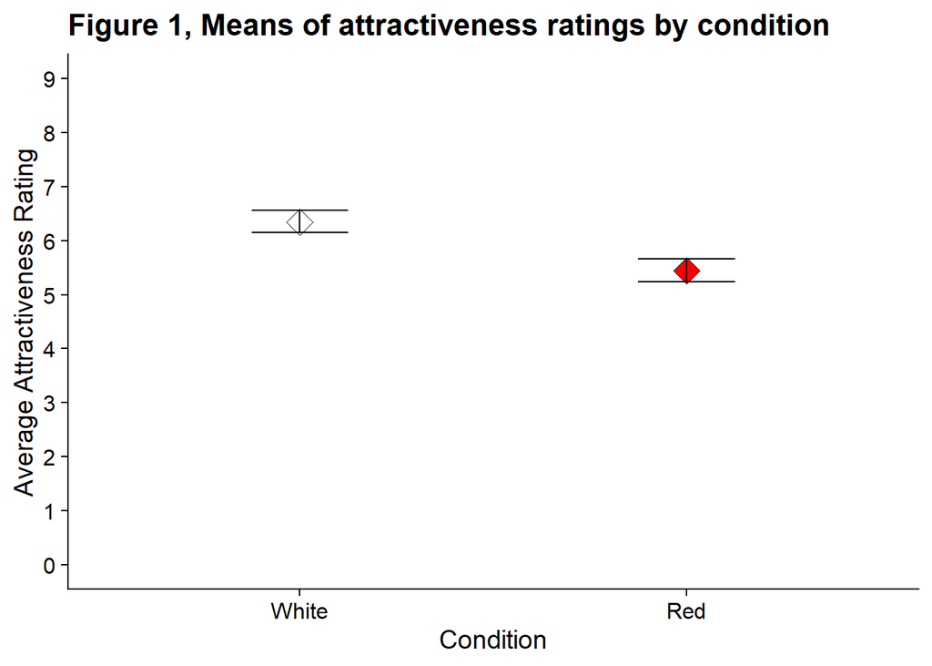

Figure 1 depicts a visual presentation of the difference between the two means, which as shown, is evident but fairly small. The standard errors for both points are also quite small, showing the minimal variation described in Table 1. The standard errors therefore suggest that the sample means are likely to be a fairly accurate representation of the true population means, and that there is not enough variation to substantially change the outcome of the results. There is therefore good reason to be confident that there is in fact a difference in means.

To investigate whether this difference is significant, an independent-samples *t*-test was used. The value of *t* was found to be 5.78, meaning the difference between the sample means was 5.78 times greater than the standard error of the difference. This difference in means was found to be significant by the *t*-test (*M*<sub>diff</sub> = 0.9, 95% CI [0.59, 1.21], *t* (118) = 5.78, *p*<.001). This indicates that we should reject the null hypothesis and accept the alternative hypothesis. The test shows that the probability of getting a *t* value of at least 5.78 is extremely small – shown by the *p*-value of <.001 – which suggests that it is highly unlikely that the two sample means come from the same population. In terms of the confidence intervals [0.59, 1.21], it is apparent that they do not contain the value 0, meaning that the true difference between means is unlikely to be 0 (the null hypothesis). To summarise, the *t*-test suggests that perceptions of attractiveness are in fact influenced by colour. In contrast to the hypothesis however, it was found that the colour white produces increased perceptions of attractiveness, instead of the colour red.

# Discussion

This study aimed to investigate the effect of the colour red on female perceptions of male attractiveness. The results suggest that there is a fairly small, but significant difference between the two sample means, as shown by the *t*-test. This analysis supports the rejection of the null hypothesis – that perception of male attractiveness is not influenced by the presence of the colour red. However, it is impossible to say what effect the colour red actually had on perceptions of attractiveness - we cannot conclude from the results that red decreases attractiveness, in the same way that we cannot conclude that the colour white increases attractiveness. We can only conclude that there is a difference between the two.

Another limitation is that it is impossible to say *why* there is a significant difference. The results show there could be some kind of phenomenon at play, but this doesn’t explain what mechanisms are involved for example, or how these mechanisms operate. A further issue is that this study only looked at female attraction to males – we cannot assume the results are generalisable across the wider population to include male attraction to females, or non-heterosexual attraction.

The original study, conducted by Elliot et al. (2010), found a very different result to the outcome of this replication. Although Elliot et al.’s study also found a significant result (*t*(20)=2.18, p<.05, d=0.95), in this replication, the significant effect was that the colour white produced higher ratings of attractiveness. In terms of the means in the original study (*M*<sub>red</sub>=6.79, and *M*<sub>white</sub>=5.67), the results appear to be very similar to this replication, just for the opposite conditions. It would be reasonable to conclude from these results that this replication found the exact opposite effect found in the original study.

Many other studies have found evidence supporting the red effect, but there is also strong evidence suggesting that the effect is trivial. One study in support of the red effect was conducted by Guéguen and Jacob (2012). They found that wearing lipstick, particularly red, significantly increases tipping behaviour at restaurants (e.g. for male patrons, 50.6% tipped waitresses wearing red lipstick compared to 30.3% for waitresses without lipstick). They found this effect occurred for male patrons only. The results were explained in terms of an increase in attractiveness and femininity. Two years prior, Guéguen (2010) completed a study using female hitchhikers – he found that “women wearing red solicited a higher response in the number of male drivers who stopped to offer a ride”. Like Guéguen and Jacobs (2012), this effect was apparent for male drivers, but not female drivers, stopping for female hitchhikers.

So, although there is good evidence for the red effect, this is primarily for male attraction to females. The vast majority of the literature reflects this, and so there is minimal evidence for the effect studied in this replication – female attraction to males. However, a meta-analysis conducted by Lehmann et al. (2018) concluded that there is indeed a significant red effect for female attraction to males, albeit very small. All of this research looks at the influence of various colours on attractiveness, and it appears that red is in fact the colour that has a positive influence. This is a stark contrast to the results of this replication, which found that the colour red was associated with lower ratings of attractiveness.

Other studies have found no effect for the influence of colour at all. For example, Peperkoorn, Roberts & Pollet (2016) completed a series of three studies, all of which failed to find support for the red effect. Furthermore, Hesslinger, Goldbach & Carbon (2015) replicated Elliot et al.’s (2010) original study, as well as a variation of it where the man was wearing either formal or casual clothing, and found no evidence of the red effect in either experiment. Both these studies support this replication in the sense that neither of them found evidence that red increases attractiveness.

It is interesting to see that Schwarz & Singer (2013) found that the red effect is only apparent in young targets, and that Young (2015) found that the red effect only influences ratings of women who are pre-rated as attractive. Looking back at Elliot’s et al.’s study it is apparent that the man used in the pictures is described as a “moderately attractive young Caucasian man”. It would be reasonable to argue that Elliot et al. may have found the effect that they did because the man they used was both “young” and “moderately attractive” – the colour of the frame therefore, may not have been the only thing influencing perceptions of attractiveness.

In terms of what that means for this replication study, we can conclude that the results found are anomalous in comparison to the other literature regarding the red effect. The replication used the exact same design and materials as Elliot et al.’s original study, yet found significant evidence for the complete opposite effect, and at p<.001. The current literature has only found either support for the specific colour ‘red’ influencing attractiveness, or no support for any colour effect at all. This presents an ideal opportunity for further research – work should be done to determine if the red effect is in fact a legitimate phenomenon, or if the same effect could be applied to other colours, such as white. Future replications should use a similar methodology but focus on investigating whether this new ‘white effect’ is just a trivial result. Furthermore, there should be an aim to increase ecological validity in future studies, as it seems that many of the studies that failed to find support for the red effect were conducted in a laboratory environment.

To conclude, this study aimed to investigate the proposed ‘red effect’ on female perceptions of male attractiveness. The results suggest that colour does increase attractiveness, however this colour is white and not red. This result is key in terms of its importance within the wider literature – it shows the presence of a ‘red effect’ for a colour that isn’t red. This is important for the discovery of other factors that influence perceptions of attractiveness. The next steps should have a focus on whether this new ‘white effect’ is an anomalous result, or a legitimate phenomenon, and if the same results can be found for other colours.

# References

Guéguen, N. (2010). Color and women hitchhikers’ attractiveness: Gentlemen drivers prefer red. *Color Research & Application, 37*(1), 76–78. Doi:

https://doi.org/10.1002/col.20651

Guéguen, N., & Jacob, C. (2012). Lipstick and tipping behavior: When red lipstick enhance waitresses tips. *International Journal of Hospitality Management, 31*(4), 1333–1335. Doi: https://doi.org/10.1016/j.ijhm.2012.03.012

Hesslinger, V. M., Goldbach, L., & Carbon, C.-C. (2015). Men in red: A reexamination of the red-attractiveness effect. *Psychonomic Bulletin & Review, 22*(4), 1142–1148. Doi: https://doi.org/10.3758/s13423-015-0866-8

Lehmann, G. K., Elliot, A. J., & Calin-Jageman, R. J. (2018). Meta-Analysis of the Effect of Red on Perceived Attractiveness. *Evolutionary Psychology, 16*(4), 1474704918802412. Doi: https://doi.org/10.1177/1474704918802412

Peperkoorn, L. S., Roberts, S. C., & Pollet, T. V. (2016). Revisiting the Red Effect on Attractiveness and Sexual Receptivity: No Effect of the Color Red on Human Mate Preferences. *Evolutionary Psychology, 14*(4), 147470491667384. Doi: https://doi.org/10.1177/1474704916673841

Schwarz, S., & Singer, M. (2013). Romantic red revisited: Red enhances men’s attraction to young, but not menopausal women. *Journal of Experimental Social Psychology, 49*. Doi: https://doi.org/10.1016/j.jesp.2012.08.004

Young, S. G. (2015). The effect of red on male perceptions of female attractiveness: Moderation by baseline attractiveness of female faces. *European Journal of Social Psychology, 45*(2), 146–151. Doi: https://doi.org/10.1002/ejsp.2098